# Baseball Data Analysis

Linear Discriminant Analysis

```r
library(MASS)

## Extract a few offensive statistics (numerical variables).
dta_st <- na.omit(dta[, c("HOF", "OBP", "SF","SLG","SB","SH")])

## Variable declarations
thresh_seq = seq(from = .05, to = .95, by = .05) # list of threshold values
n <- nrow(dta) # stores number of rows in the data set

lda_out <- lda(HOF ~., data=dta_st, CV = TRUE)
sens_lda <- spec_lda <- bacc_lda <-NULL
for(i in 1:length(thresh_seq)) {
  class_lda <- lda_out$posterior[,2] > thresh_seq[i]
  # filters results by players who are actually in the HOF (Y), then checks if TRUE was predicted. The average of the correct YES predictions defines sensitivity
  sens_lda[i] <- mean(class_lda[dta_st$HOF == 'Y'] == TRUE)
  # filters results by players who are actually NOT in the HOF (N), then checks if FALSE was predicted. The average of the correct YES predictions defines sensitivity
  spec_lda[i] <- mean(class_lda[dta_st$HOF == 'N'] == FALSE)
  bacc_lda[i] <- (sens_lda[i] + 3*spec_lda[i]) / 4 # balance accuracy calculation is weighted
  results1 <- as.data.frame(cbind(sens_lda, spec_lda, bacc_lda))
}

spec2 <- 1-spec_lda
roc_dat1<-data.frame(x=spec2,y=sens_lda)

roc1 <- ggplot(roc_dat1) + geom_point(aes(roc_dat1$x,roc_dat1$y),size=2) + labs(title= "LDA ROC Curve",
                                                        x = "False Positive Rate (1-Specificity)",
                                                        y = "True Positive Rate (Sensitivity)")
results1
```

```
##     sens_lda  spec_lda  bacc_lda
## 1  0.8775510 0.8726708 0.8738909
## 2  0.7959184 0.9161491 0.8860914
## 3  0.6938776 0.9378882 0.8768855
## 4  0.6530612 0.9461698 0.8728926
## 5  0.6326531 0.9554865 0.8747782
## 6  0.5918367 0.9596273 0.8676797
## 7  0.5306122 0.9658385 0.8570319
## 8  0.5102041 0.9699793 0.8550355
## 9  0.4285714 0.9792961 0.8416149
## 10 0.4081633 0.9834369 0.8396185
## 11 0.4081633 0.9855072 0.8411713
## 12 0.3469388 0.9875776 0.8274179
## 13 0.3265306 0.9906832 0.8246451
## 14 0.2653061 0.9927536 0.8108917
## 15 0.2653061 0.9927536 0.8108917
## 16 0.2244898 0.9958592 0.8030169
## 17 0.2244898 0.9989648 0.8053461
## 18 0.1428571 0.9989648 0.7849379
## 19 0.1020408 0.9989648 0.7747338
```

Generalized Linear Model

```r
## Extract a few offensive statistics (numerical variables).
dta_st <- dta[, c("HOF", "OBP", "SF","SLG","SB","SH")]

## Variable declarations
fit_pred <- matrix(rep(0,n), nrow=n, ncol=1)

for(i in 1:n) {
  fit <- glm(HOF ~., data = dta_st[-i,], family = binomial()) #uses all values but one as training data
  fit_pred[i] <- predict(fit, newdata = dta_st[i,], type = 'response') # uses remaining value to predict
}

sens_glm <- spec_glm <- bacc_glm <-NULL
for(i in 1:length(thresh_seq)) {
  class_glm <- fit_pred > thresh_seq[i]
  # filters results by players who are actually in the HOF (Y), then checks if TRUE was predicted. The average of the correct YES predictions defines sensitivity
  sens_glm[i] <- mean(class_glm[dta_st$HOF == 'Y'] == TRUE)
  # filters results by players who are actually NOT in the HOF (N), then checks if FALSE was predicted. The average of the correct YES predictions defines sensitivity
  spec_glm[i] <- mean(class_glm[dta_st$HOF == 'N'] == FALSE)
  bacc_glm[i] <- (sens_glm[i] + 3*spec_glm[i]) / 4
  results2 <- as.data.frame(cbind(sens_glm, spec_glm, bacc_glm))
}

spec2 <- 1-spec_glm
roc_dat2<-data.frame(x=spec2,y=sens_glm) # data for roc curve

roc2 <- ggplot(roc_dat2) + geom_point(aes(roc_dat2$x,roc_dat2$y),size=2) + labs(title= "GLM ROC Curve",
                                                         x = "False Positive Rate (1-Specificity)",
                                                         y = "True Positive Rate (Sensitivity)")

results2
```

```
##      sens_glm  spec_glm  bacc_glm
## 1  0.91836735 0.8954451 0.9011757
## 2  0.89795918 0.9327122 0.9240240
## 3  0.81632653 0.9523810 0.9183673
## 4  0.71428571 0.9585921 0.8975155
## 5  0.67346939 0.9710145 0.8966282
## 6  0.55102041 0.9741201 0.8683452
## 7  0.53061224 0.9761905 0.8647959
## 8  0.48979592 0.9792961 0.8569210
## 9  0.38775510 0.9824017 0.8337400
## 10 0.38775510 0.9865424 0.8368456
## 11 0.38775510 0.9896480 0.8391748
## 12 0.36734694 0.9917184 0.8356256
## 13 0.28571429 0.9958592 0.8183230
## 14 0.26530612 0.9979296 0.8147737
## 15 0.24489796 0.9979296 0.8096717
## 16 0.20408163 0.9979296 0.7994676
## 17 0.14285714 0.9989648 0.7849379
## 18 0.12244898 1.0000000 0.7806122
## 19 0.06122449 1.0000000 0.7653061
```

Sensitivity and Specificity are based the rate of true positives and true negatives, respectively. In a confusion matrix, which compares predictions to actual values, the effectiveness of a model can be easily determined. A perfect model would only result in a confusion matrix that only features data on the diagonal. This would signify that every positive (bottom right) and negative (top left) prediction was correct.

```r
avglda <- mean(sens_lda)
avgglm <- mean(sens_glm)

lda_out <- lda(HOF ~., data = dta_st)
lda_pred <- predict(lda_out, newdata = dta_st)$class

confmat <- table(lda_pred, dta_st$HOF)
confmat
```

```
##
## lda_pred   N   Y
##        N 951  27
##        Y  15  22
```

```r
avglda
```

```
## [1] 0.443609
```

```r
avgglm
```

```
## [1] 0.4446831
```

Results and Conclusion

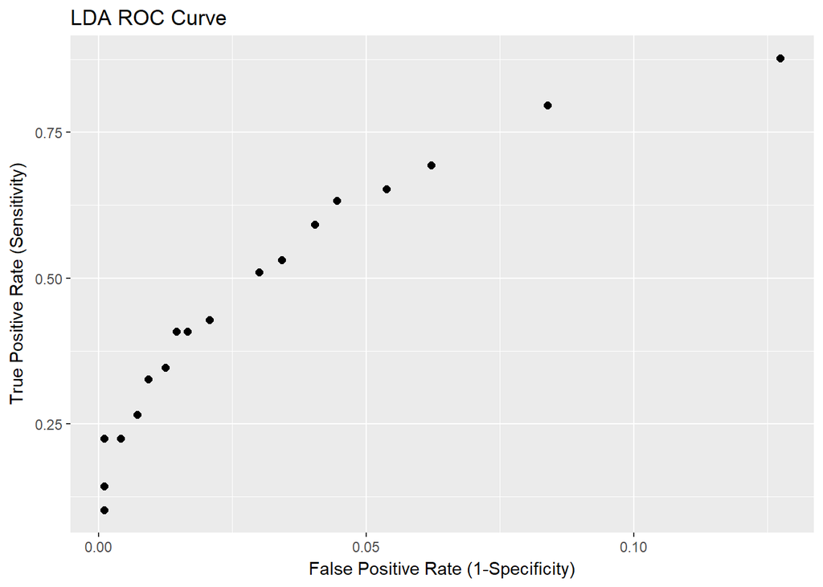

```r
plot(roc1)
```

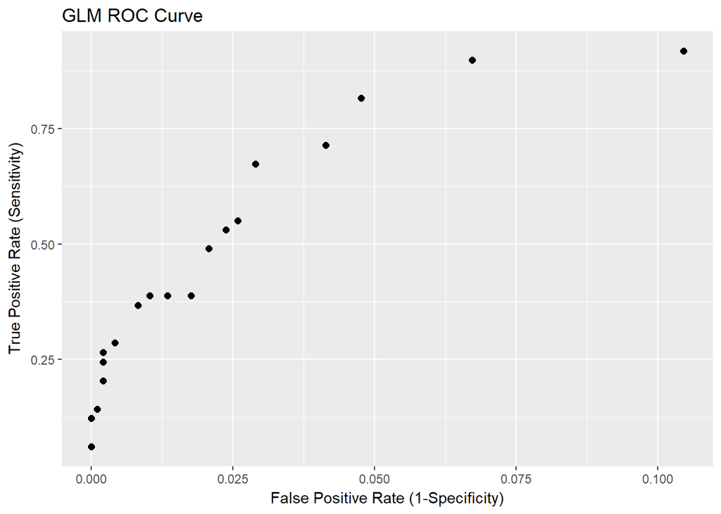

```r
plot(roc2)
```

Comparing Receiver Operator Characteristic (ROC) curves is a fast way to compare models and gain a general understanding of their effectiveness. An ideal ROC curve will maximize sensitivity, while minimizing 1-speciicity. This would manifest in a graph as the curve only being present on the leftmost side for as much of the y-axis as possible.

The glm graph shows that it was able to achieve slightly better rates for true positives and negatives. This is a valuable result that can be quickly observed from an ROC curve. Using this information, optimizations for threshold values and variables can improve sensitivity, specificity, and balanced accuracy. The glm prediction was able to generate an accuracy of over 90%. which the lda prediction wasn’t able to do with the given model.

Specificity was similar between the two methods, which is to be expected given the fact that the vast majority of players are not in the Hall of Fame. Predicting no for every player would give good specificity, but clearly wouldn’t be an effective tool. The average sensitivity was also extremely close between the two models. This is reflected in the ROC curves as well. Paying more attention to correlation between variables in the model could improve the distinction between the two methods in the future.